# R Stats Notebook

# Manipulating Data

## subset

subsetting keeps it as a data frame

```r
library(ISwR)
data("energy")
energy2 = subset(energy, expend < 7.5)
```

qualitative subsetting

```r
energy3 = subset(energy, stature == "obese",
                 select = expend:structure)
```

can also separate into two separate vectors:

```r
exp.lean = energy$expend[energy$stature == "lean"]
exp.lean
exp.obese = energy$expend[energy$stature == "obese"]
exp.obese
```

## Transforming data

```r
energy4 <- transform(energy, log.expend = log(expend))
                    #dataset ##column name ##transformation
```

## Implicit Loops

multiple ways to do this: lapply() –> *always* returns a list sapply() –> *simplifies* result into a *matrix* apply() –> works on *matrices* not data frames tapply() –> creates a *table* as output

## The Aggregate Function

Summarizing data from one variable based on a second variable (usally a category) aggregate() –> splits the data into subsets, computes summary statistics for each, and returns the result aggregate(x, by, FUN, .., simlify = TRUE)

```r
aggregate(energy$expend, by = list(stature = energy$stature), mean, na.rm = TRUE)
```

## The Tidyverse Method

```r
energy %>%
  group_by(stature) %>%
  summarise(mean_value = mean(expend))
```

returns a *tibble* format

# Importing Data

read.table(file, header = FALSE, sep = ““)

```r
read.table("~/Desktop/Academic/M.S. Biology/Advanced Stats/Adv Stats in R /Owls.txt", header = TRUE)
```

can also use “read.csv()” for .csv files

# Exercise

1. calculate mean arrival time for males and females

```r
library(tidyverse)
Owls %>%
  group_by(SexParent) %>%
  summarise(mean.value = mean(ArrivalTime))
```

2. mean arrival time for each food treatment

```r
library(tidyverse)
Owls %>%
  group_by(FoodTreatment) %>%
  summarise(mean.value = mean(ArrivalTime))
```

3. sep. vectors of farrival times for each sex

```r
male.arrivals <- Owls[Owls$SexParent == "Male", ArrivalTime]
```

```
Error: object 'ArrivalTime' not found
```

4. sep dataframes of complete data set for each sex
5. mean arrival time for each sex for each food treatment

| SexParent | FoodTreatment | mean.value |
| --- | --- | --- |
| Female | Deprived | 24.75935 |
| Female | Satiated | 24.62336 |
| Male | Deprived | 24.87401 |
| Male | Satiated | 24.71459 |

# Plotting

```r
Veg <- read_csv("Vegetation2.csv")
```

## scatterplot

Can be done two different ways:

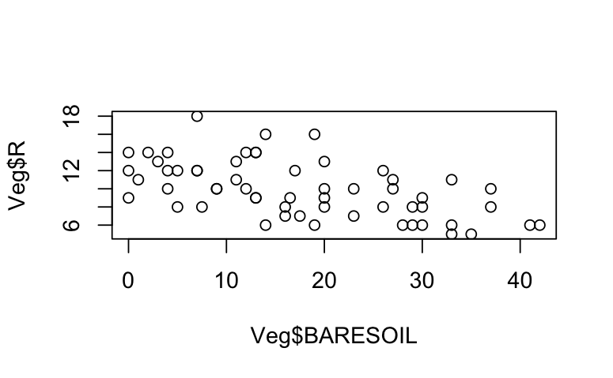

or (recommended) using a formula:

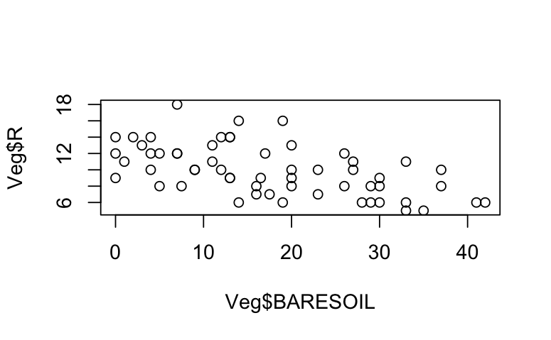

Plotting with *labels*

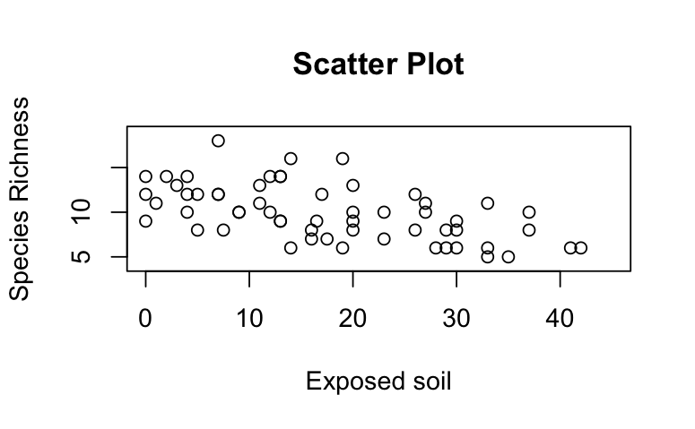

Able to change the plotting character (pch) to match specific transects in the data

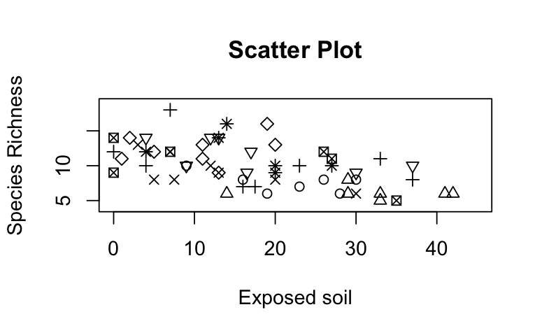

Use of a vector for pch arguments:

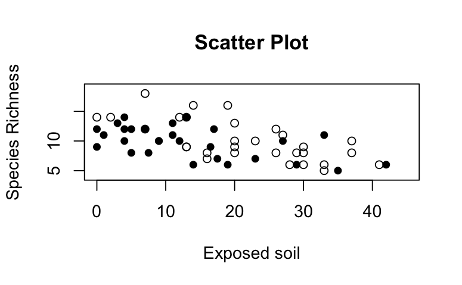

Change the character size with ‘cex’

## Boxplot

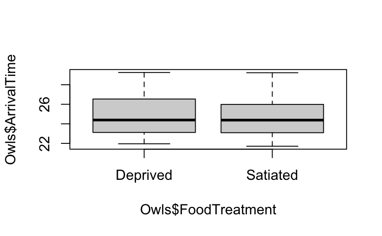

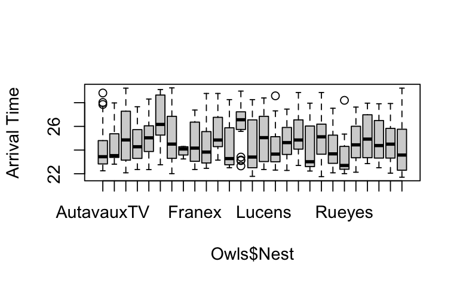

## Histogram

Great for visualizing distributions

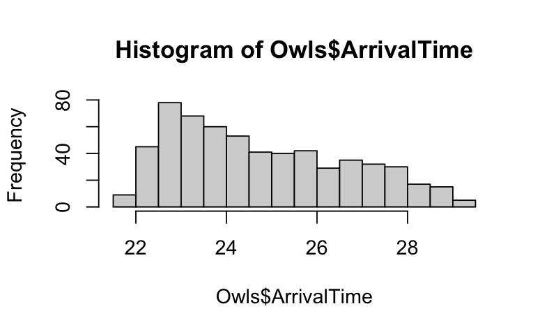